# Istanbul Mini Project

## Intro

Estimation and Comparison of **Prediction Intervals** using **QRLSTM** and **Historical Forecast Similarity** on Istanbul’s Traffic Data.

Evaluation and Comparison of 2 different approaches:

1. **QRLSTM:**
   - Directly estimates wanted **quantiles** with an **LSTM network**.
   - Called QRLSTM because of the unique **loss function** that is **uneven** weighted
   - Using the specific quantiles for creating **Prediction Intervals**
2. **Forecast Similarity**
   - First, makes a **point estimate** of the traffic flow.
   - Then, uses these estimations as a **time–series** data
   - Creates **time-windows** of forecast-time-series data
   - Calculates the **similarity** between different time-windows using **different metrics**
   - Using **similar time windows** for creating **Prediction Intervals**

## Data

The data provided had many missing instances.

4 different methods for handling missing data (not to be included in this report)

1. Remove NA
2. Using ARIMA for predicting missing data
3. Mean of every same hour
4. Mean of every same hour of the same day (e.g. Monday 4:00)

## QRLSTM

A peek to the input of LSTM network:

```r
head(a1)
```

| index | flow_lag169 | flow_lag168 | flow_lag167 | flow_lag25 | flow_lag24 | flow_lag23 | flow_lag2 | flow_lag1 | flow |
| --- | --- | --- | --- | --- | --- | --- | --- | --- | --- |
| 169 | 0.2327139 | 0.2143417 | 0.1980109 | 0.15514257 | 0.11023288 | 0.09390208 | 0.26945814 | 0.23067250 | 0.14493582 |
| 170 | 0.2143417 | 0.1980109 | 0.1286050 | 0.11023288 | 0.09390208 | 0.07552993 | 0.23067250 | 0.14493582 | 0.11431558 |
| 171 | 0.1980109 | 0.1286050 | 0.1081915 | 0.09390208 | 0.07552993 | 0.12043963 | 0.14493582 | 0.11431558 | 0.08981938 |
| 172 | 0.1286050 | 0.1081915 | 0.1020675 | 0.07552993 | 0.12043963 | 0.23271385 | 0.11431558 | 0.08981938 | 0.11227423 |
| 173 | 0.1081915 | 0.1020675 | 0.1204396 | 0.12043963 | 0.23271385 | 0.79612634 | 0.08981938 | 0.11227423 | 0.26129275 |
| 174 | 0.1020675 | 0.1204396 | 0.1592253 | 0.23271385 | 0.79612634 | 0.84716007 | 0.11227423 | 0.26129275 | 0.68181076 |

QRLSTM code:

```r
# tau = 0.05 / data = d1
qrlstm05_d1 <- keras_model_sequential()
# LSTM > SOFTMAX > OUTPUT
qrlstm05_d1 %>%
    layer_lstm(units = 8, input_shape = c(9,1)) %>%
    layer_activation_softmax() %>%
    layer_dense(units = 1)
# ADAM / LEARNING RATE = 0.001 / QUANTILE(PINBALL) LOSS
qrlstm05_d1 %>%
    compile(loss = pinball_loss05,
            optimizer = optimizer_adam(learning_rate = 0.001),
            metrics = 'mae')
# BATCHSIZE = 1 (changing it to 10 might be much much faster with same performance, not sure though)
fit_qr05_d1 <- qrlstm05_d1 %>% fit(
    x = t1ax,
    y = t1ay,
    batch_size = 1,
    epochs = 30,
    verbose = 1,
    shuffle = FALSE
)

## tau = 0.95
qrlstm95_d1 <- keras_model_sequential()

qrlstm95_d1 %>%
    layer_lstm(units = 8, input_shape = c(9,1)) %>%
    layer_activation_softmax() %>%
    layer_dense(units = 1)
#
qrlstm95_d1 %>%
    compile(loss = pinball_loss95,
            optimizer = optimizer_adam(learning_rate = 0.001),
            metrics = 'mae')


fit_qr95_d1 <- qrlstm95_d1 %>% fit(
    x = t1ax,
    y = t1ay,
    batch_size = 10,
    epochs = 30,
    verbose = 1,
    shuffle = FALSE
)
```

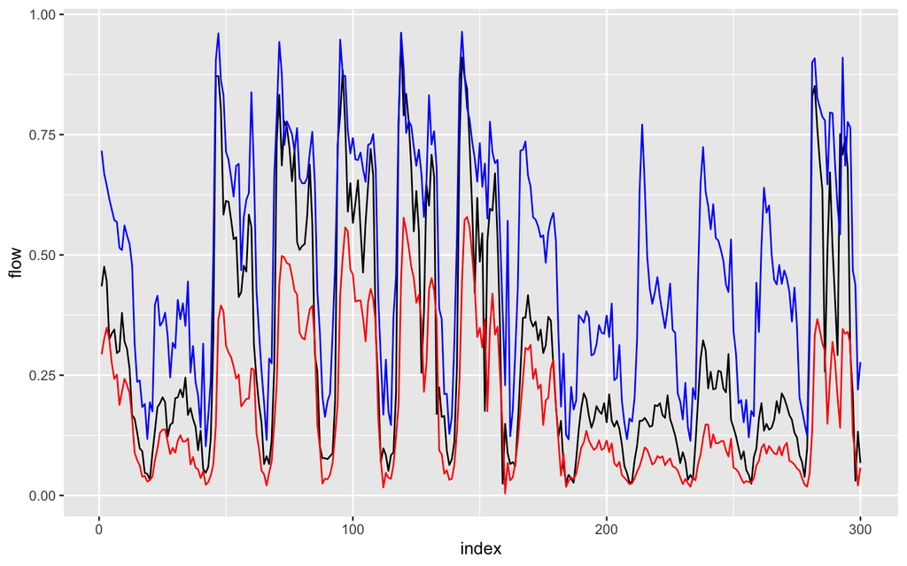

```r
ggplot(te1all[1:300,]) +
    geom_line(mapping = aes(x = index, y = flow), color = "black") +
    geom_line(mapping = aes(x = index, y = upper), color = "blue") +
    geom_line(mapping = aes(x = index, y = lower), color = "red")
```

We see that model1 covers the flow inside the interval, nicely. However, it sometimes has very big intervals.

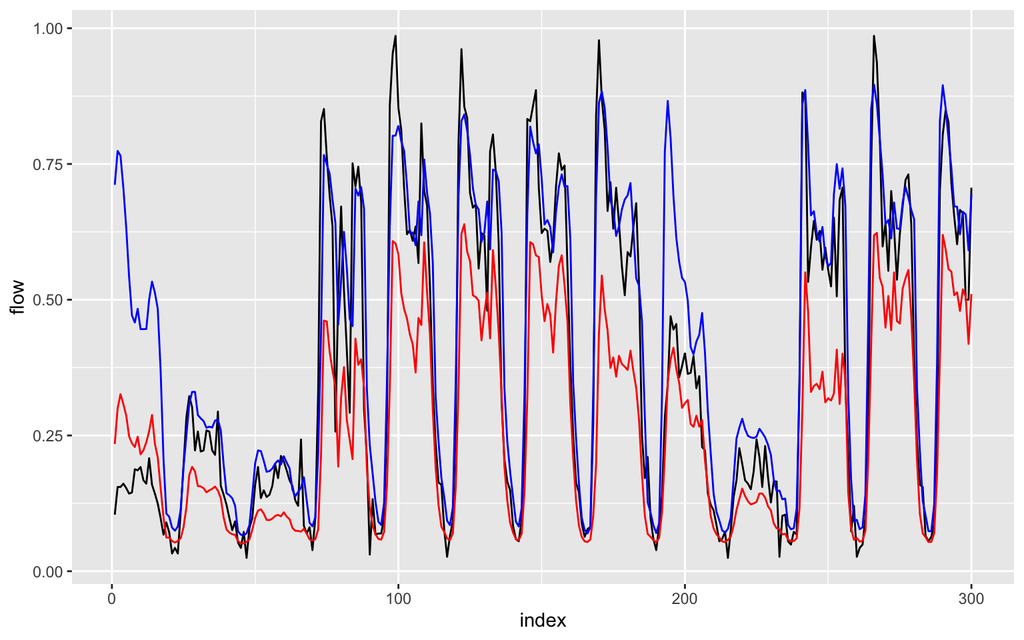

```r
ggplot(te3all[1:300,]) +
    geom_line(mapping = aes(x = index, y = flow), color = "black") +
    geom_line(mapping = aes(x = index, y = upper), color = "blue") +
    geom_line(mapping = aes(x = index, y = lower), color = "red")
```

In model2, the intervals are smaller compared to model1. However, we see that there are many cases where the flow leaves the interval. Thus we are expecting a bad UC score.

Winkler Score and Unconditional Coverage

| Data | Winkler Train | Winkler Test | Unconditional Coverage Train | Unconditional Coverage Test |
| --- | --- | --- | --- | --- |
| Data1 | 0.3182632 | 0.3231521 | 0.9218062 | 0.9144954 |
| Data2 | 0.2177761 | 0.2219309 | 0.7706763 | 0.7710508 |
| Data3 | 0.1957726 | 0.1909628 | 0.6790396 | 0.7146834 |
| Data4 | 0.1928564 | 0.1887284 | 0.6926111 | 0.7174669 |

Smaller winkler score is better

UC should be as close to 0.90 as possible. However we have some weird results here.

## Forecast Similarity

Using point LSTM forecast results, closest 20 neighbors are chosen.

The measuring was euclidean distance on 10 hour time-windows.

The results are as shown:

The Main Table. Comparison of winkler and UC scores.

| Data | Winkler Score | Unconditional Coverage |
| --- | --- | --- |
| Data1 | 0.2419179 | 0.8235727 |
| Data2 | 0.2218581 | 0.7503492 |
| Data3 | 0.2319301 | 0.8365922 |
| Data4 | 0.2305406 | 0.8400838 |

## Results

[output not shown]

We see mixed results.

**For UC Coverage:** in first two datasets QRLSTM performs better. However all these results except QRLSTM on Data1 are problematic. Forecast similarity was a hand-made approach, so its UC coverage might be a little off, however QRLSTM’s inaccuracy is surprising.